# Afleveringliv

Oskar Allerslev, Hugo Hendil, Emanuel Konrad

2024-12-11

# Indlæsning af data

```r
m1 <- read.csv("mort1.csv", sep = ";", dec = ",")
m1fun <- approxfun(m1$Alder, m1$mu, rule = 2)
mu02star <- function(t){ m1fun(t+30) }
```

# Opgave a)

I opgave a) og b) vil vi undertrykke notationen for reserverne og de tilhørende objekter.

Vi bemærker at der ikke er klumpbetalinger. Vi opskriver vores *reward* som $R(t)=\Lambda^1(t) * B(t)+ \Delta(b(t))$.

$$\begin{align*}
R^\circ(t)=\begin{bmatrix}
\left(-\pi \cdot 1_{\{t\leq 35 \}}+400K \cdot 1_{\{t > 35\}}\right)
& 0 & 0 \\
0 & 400K & 0 \\
0 & 0 & 0
\end{bmatrix}
\end{align*}$$

Vi har dertil også:

$$\begin{align*}
dB^\circ(t) &= \sum_{i \in E} \left( 1_{\{ X(t-)=i\}}
b^\circ_i(t)dt\right)\\
&=-\pi \cdot 1_{\{t\leq 35 \cap X(t-)=1 \}}dt+400K \cdot 1_{\{t>
35 \cap X(t-)=1 \}}dt+400K \cdot 1_{\{ X(t-)=2 \}}dt
\end{align*}$$
Det skyldes vi ikke har klumpbetalinger. Den afhænger ikke af antagelserne fra førsteordensgrundlaget.

# opgave b)

En vigtig antagelse for at man kan regne ækvivalenspræmien er at $R(t)=R(t;\theta)$. Det er også gældende i vores tilfælde, da $\theta$ bare er præmieraten, hvorfor vi kan benytte os af Newtons algoritme til at finde ækvivalenspræmien. Vi vælger at skrive vores udtryk på vektor-form. Bemærk $t\in(0,80)$. Dertil er de prospektive reserver givet:

$$\begin{align*}
V^{th}(t;\pi) &= \int_{t}^{80}e^{-\int_{t}^u 0.01dx} P(0,u)R^{\circ
*}(u)edu\\
&=\int_{t}^{80} e^{-\int_t^u 0.01 dx}
\begin{bmatrix}
p_{11}(0, u) & p_{12}(0, u) & p_{13}(0, u) \\
p_{21}(0, u) & p_{22}(0, u) & p_{23}(0, u) \\
p_{31}(0, u) & p_{32}(0, u) & p_{33}(0, u)
\end{bmatrix}
\begin{bmatrix}
\left(-\pi \cdot 1_{\{t\leq 35 \}}+400K \cdot 1_{\{t >
35\}}\right) \\
400K \\
0
\end{bmatrix}
du
\\
&=\begin{bmatrix}
\int_t^{80}e^{-\int_t^u 0.01 dx}p_{11}(0,u)\left(-\pi \cdot 1_{\{t\leq
35 \}}+400K \cdot 1_{\{t > 35\}}\right)+p_{12}(0,u)(400K )du\\
\int_t^{80}e^{-\int_t^u 0.01 dx}p_{21}(0,u)\left(-\pi \cdot 1_{\{t\leq
35 \}}+400K \cdot 1_{\{t > 35\}}\right)+p_{22}(0,u)(400K )du\\
0
\end{bmatrix}.
\end{align*}$$
Vi har også
$$\begin{align*}
V^{th}_1(0;0)=\int_0^{80}e^{-\int_0^u 0.01 dx}p_{11}(0,u)\left(400K
\cdot 1_{\{t > 35\}}\right)+p_{12}(0,u)(400K )du,
\end{align*}$$
samt
$$\begin{align*}
\frac{\partial}{\partial \pi}V^{th}_1(0;\pi)= \int_0^{80}e^{-\int_0^u
0.01 dx}p_{11}(0,u)\left(-\pi \cdot 1_{\{t\leq 35 \}}\right)du
\end{align*}$$
Hertil er ækvivalenspræmien givet ved:
$$\begin{align*}
\mu = \frac{V^{th}_1(0;0)}{\frac{\partial}{\partial \pi}V^{th}_1(0;\pi)}
= \frac{\int_0^{80}e^{-\int_0^u 0.01 dx}p_{11}(0,u)\left(400K \cdot
1_{\{t > 35\}}\right)+p_{12}(0,u)(400K )du }{
\int_0^{80}e^{-\int_0^u 0.01 dx}p_{11}(0,u)\left(-\pi \cdot 1_{\{t\leq
35 \}}\right)du}
\end{align*}$$

# Opgave c)

Vi benytter *RK4* til at regne vores produktintegral. Nedenstående kode er (i stort omfang) kopieret fra den kode vi har fået udleveret. Den udgør vores beregning af produktintegralet.

```r
prodint <- function(A, s, t, n) {
  x0 <- s
  y0 <- diag(nrow(A(s)))
  h <- (t - s) / n
  for (i in 1:n) {
    s1 <- h * y0 %*% A(x0)
    s2 <- h * (y0 + s1 / 2) %*% A(x0 + h / 2)
    s3 <- h * (y0 + s2 / 2) %*% A(x0 + h / 2)
    s4 <- h * (y0 + s3) %*% A(x0 + h)
    y0 <- y0 + s1 / 6 + s2 / 3 + s3 / 3 + s4 / 6
    x0 <- x0 + h
  }
  return(y0)
}



Lambda <- function(x) {

  A <- matrix(0, 3, 3)


  A[1, 2] <- (0.0004 + 10^(4.54 + 0.06*(x+30)-10))*ifelse(x <= 35, 1, 0)
  A[1,3]  <- mu02star(x)
  A[2,1] <- 2.0058 * exp(-0.117*(x+30)) * ifelse(x <= 35,1,0)
  A[2,3] <- A[1,3]*(1+ifelse(x <= 35,1,0))

  row_sums <- rowSums(A)
  diag(A) <- -row_sums

  return(A)
}


R <- function(x, mu) {
  if (x <= 35) {
    return(diag(c(-mu , 400000, 0)))
  } else {
    return(diag(c(400000, 400000,0)))
  }
}

dR <- function(x, mu) {
  if (x <= 35) {
    return(diag(c(-1, 0,0)))
  } else {
    return(diag(c(0,0,0)))
  }
}

reserve <- function(t, TT, Lambda, R, mu, rint, N) {
  dim <- nrow(Lambda(t))
  A11 <- function(x) {
    return(Lambda(x) - rint * diag(1, nrow = dim))
  }
  RM <- function(x) {
    cbind(rbind(A11(x), matrix(0, dim, dim)), rbind(R(x, mu), Lambda(x)))
  }
  PRM <- prodint(RM, t, TT, N)
  RES <- PRM[1:dim, (dim + 1):(2 * dim)]
  return((RES %*% rep(1, dim)))
}

equiv_premium <- function(t, TT, Lambda, R, dR, mu, rint, numsteps) {
  b <- reserve(t, TT, Lambda, R, 0.0, rint, numsteps)
  a <- reserve(t, TT, Lambda, dR, 0.0, rint, numsteps)
  return(-b / a)
}

equiv_premium(0, 80, Lambda, R, dR, 0.0, 0.01, 5000)[1]
```

```
## [1] 209640.5
```

# Opgave d)

```r
V_20_ <- reserve(20, 80, Lambda, R, 209640.5, 0.01, 1000)
V_35_ <- reserve(35, 80, Lambda, R, 209640.5, 0.01, 1000)

data.frame( "V(20)" = V_20_, "V(35)" = V_35_)
```

| V.20. | V.35. |
| --- | --- |
| 4326519 | 8199113 |
| 11712299 | 8203330 |
| 0 | 0 |

Vi observerer vores resultater er i overenstemmelse med den standard fortolkning af prospektive reserver.

# opgave e)

Vi benytter
$$\begin{align*}
\frac{\partial}{\partial t} V_i^{\circ,
*}(t)=(r^*(t)-\Lambda^*(t))V_i^{\circ, *}(t)-R^{\circ *}(t)e.
\end{align*}$$

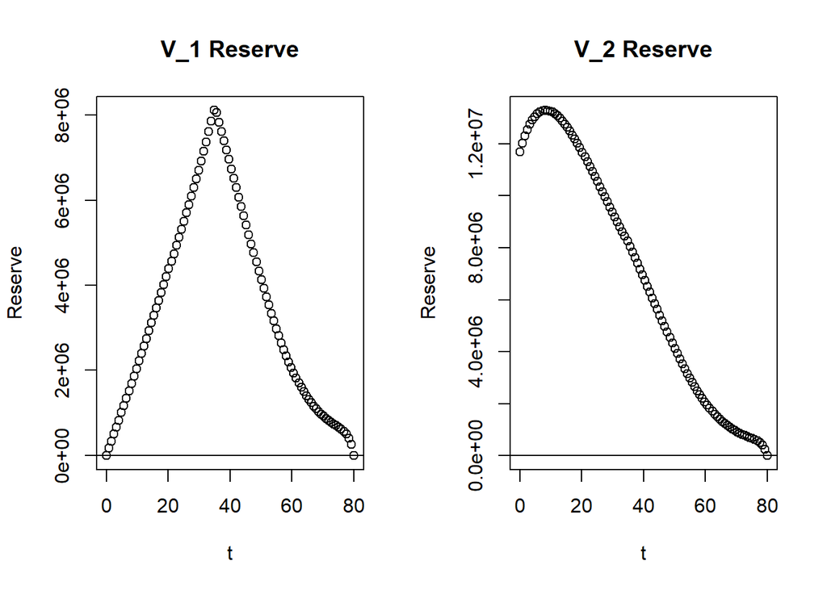

```r
TT <- 80
eq <- 209640.5
rint <- 0.01
N <- 1000

x_vals <- seq(0, TT, length.out = 100)

y_vals <- sapply(x_vals, function(t) {
  res_mat <- reserve(t, TT, Lambda, R, eq, rint, N)
  v <- res_mat
  c(V_1 = v[1], V_2 = v[2])
})

y_vals <- t(y_vals)

results <- data.frame(x = x_vals, V_1 = y_vals[,1], V_2 = y_vals[,2])

par(mfrow = c(1, 2))
plot(results$x, results$V_1, xlab = 't', ylab = 'Reserve', main = 'V_1 Reserve')
abline(0,0)
plot(results$x, results$V_2, xlab = 't', ylab = 'Reserve', main = 'V_2 Reserve')
abline(0,0)
```

Vi bemærker at reserverne for de to tilstande er som forventet. De er i overenstemmelse med den standard fortolkning af prospektive reserver for henholdsvis aktiv og invalid. ‘Knækket’ omkring $t=70$ kan skyldes, vi ikke skelner mellem intensiteter for mænd og kvinder. Det kan også tænkes at være en måde vi inkorporere halerisikoen for de ældre.

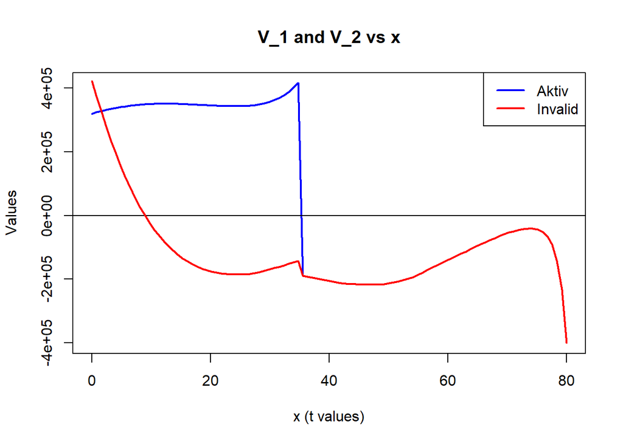

```r
diff_partial_thiele <- function(t,TT=80, eq =209640.5 , rint = 0.01, N=1000){
  result <- (rint - Lambda(t)) %*% reserve(t, TT, Lambda, R, eq, rint, N)  - R(t,eq) %*% rep(1,3)
  c(V_1 = result[1], V_2 =result[2])
}

x_vals <- seq(0, 80, length.out = 100)
y_vals <- t(sapply(x_vals, diff_partial_thiele))

results <- data.frame(x = x_vals, V_1 = y_vals[, 1], V_2 = y_vals[, 2])

plot(results$x, results$V_1, type = "l", col = "blue", lwd = 2,
     xlab = "x (t values)", ylab = "Values", main = "V_1 and V_2 vs x")
abline(a = 0, b = 0)
lines(results$x, results$V_2, col = "red", lwd = 2)
legend("topright", legend = c("Aktiv", "Invalid"), col = c("blue", "red"), lty = 1, lwd = 2)
```

Man kan igen her se at differentialligningerne er som forventet og i overenstemmelse med de reserver vi plottede ovenfor denne.

# Opgave f)

Vi finder her standardafvigelsen ved brug af $(2.29)$ (udtrykket i forelæsningsnoterne) til at finde $(2.30)$ (udtrykket i forlæsningsnoterne) hvilket konkret beregnes ved:
$$\begin{align*}
\prod_s^t (I+F^{(k)}(x)dx)=H^{(k)}(s,t).
\end{align*}$$

```r
eq <- 209640.5

R <- function(x, mu) {
  if (x <= 35) {
    return(diag(c(-mu , 400000, 0)))
  } else {
    return(diag(c(400000, 400000,0)))
  }
}

Fu <- function(Lambda, R){
  I <- base::diag(x=1, nrow = 3, ncol = 3)
  k=2
  r = 0.01
  A <- matrix(0,9,9)
  A[1:3, 1:3] <- Lambda- k*r*I
  A[4:6, 4:6] <- Lambda - (k-1)*r*I
  A[7:9, 7:9] <- Lambda - (k-2)*r*I
  A[1:3, 4:6] <- R
  A[4:6,7:9] <- R
  return(A)
}

ABE <- function(u){
  Fu(Lambda(u),R(u,eq))

}

resultat <- prodint(ABE, 0, 80, 10000)

sqrt((2*resultat[1:3,7:9]-resultat[4:6,7:9]^2) %*% rep(1,3))[1]
```

```
## [1] 2952402
```

# Opgave g)

Først definerer vi vores nye rentefunktion vha. interpolation (som også gjort tidligere). Derudover konstruerer vi også vores $\Lambda(t)$.

```r
m2 <- read.csv("ftmort.csv", sep = ";", dec = ",")
m2fun <- approxfun(m2$Alder, m2$mu, rule = 2)
mu202star <- function(t){ m2fun(t+30) }

rente <- read.csv("rente.csv", sep = ";", dec = ",")
rentefun <- approxfun(rente$t, rente$rt, rule = 2)
rentefunk <- function(t){rentefun(t)}

Lambda1 <- function(x) {
  A <- matrix(0, 3, 3)
  A[1, 2] <- (10^(5.662015+0.033462*(x+30)-10))*ifelse(x <= 35, 1, 0)
  A[1,3]  <- mu202star(x)
  A[2,1] <- 4.0116*exp(-0.117*(x+30))*ifelse(x<=35,1,0)
  A[2,3] <- (0.010339+10^(5.070927+0.05049*(x+30)-10))*ifelse(x <= 35,1 ,0 )+ A[1,3]*ifelse(x>35,1,0)
    row_sums <- rowSums(A)
  diag(A) <- -row_sums
  return(A)
}
```

Vi regner nu risikosummerne. Jf. vi stadig ikke har nogle klumpbetalinger benyttes:
$$\begin{align*}
RS^{*, \circ}_{ik}(t)=V_k^{*, \circ}(t)-V_i^{*, \circ}(t).
\end{align*}$$

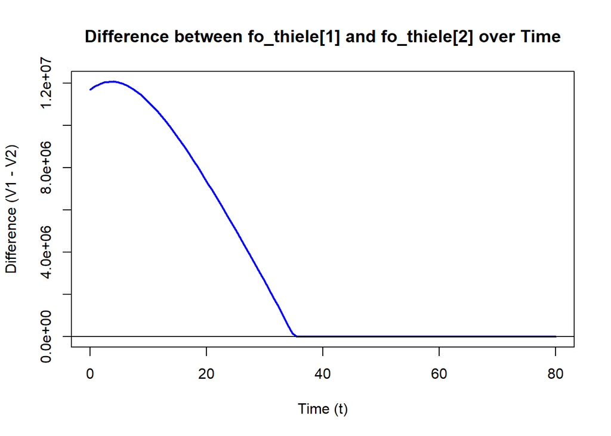

```r
TT <- 80
eq <- 209640.5
rint <- 0.01
N <- 1000

time_points <- seq(0, TT, length.out = 100)

differences <- numeric(length(time_points))

for (i in seq_along(time_points)) {
  t <- time_points[i]
  fo_thiele <- reserve(t, TT, Lambda, R, eq, rint, N) %*% rep(1, 3)
  differences[i] <- fo_thiele[2] - fo_thiele[1]
}

plot(time_points, differences, type = "l", col = "blue", lwd = 2,
     xlab = "Time (t)", ylab = "Difference (V1 - V2)",
     main = "Difference between fo_thiele[1] and fo_thiele[2] over Time")
abline(a = 0, b = 0)
```

Vi regner nu det samme for tredjeordensgrundlaget:

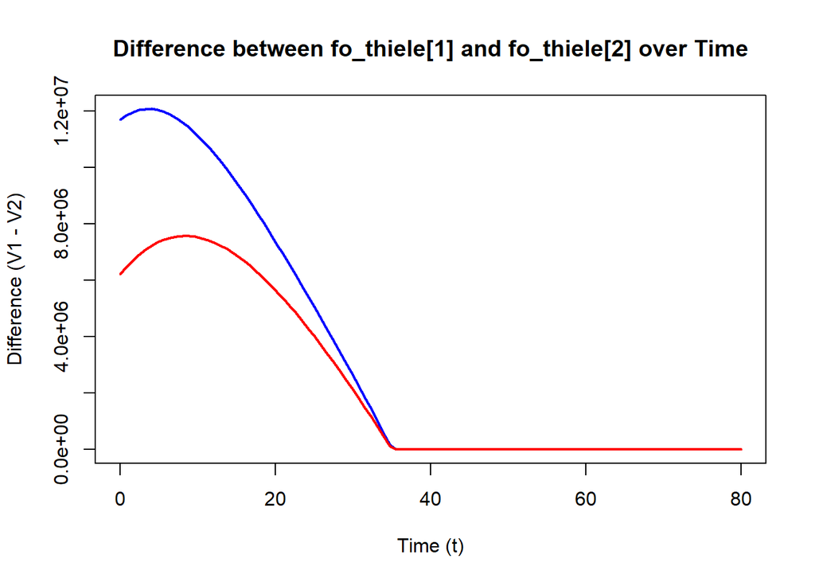

```r
reserveR <- function(t, TT, Lambda, R, mu, r, N) {
  dim <- nrow(Lambda(t))
  A11 <- function(x) {
    return(Lambda(x) - r(x) * diag(1, nrow = dim))
  }
  RM <- function(x) {
    cbind(rbind(A11(x), matrix(0, dim, dim)), rbind(R(x, mu), Lambda(x)))
  }
  PRM <- prodint(RM, t, TT, N)
  RES <- PRM[1:dim, (dim + 1):(2 * dim)]
  return((RES %*% rep(1, dim)))
}

time_points_1 <- seq(0, 80, length.out = 100)

differences1 <- numeric(length(time_points))

for (i in seq_along(time_points)) {
  t <- time_points[i]
  fo_thiele <- reserveR(t,80,Lambda1,R,eq,rentefunk,1000)
  differences1[i] <- fo_thiele[2] - fo_thiele[1]
}

plot(time_points, differences, type = "l", col = "blue", lwd = 2,
     xlab = "Time (t)", ylab = "Difference (V1 - V2)",
     main = "Difference between fo_thiele[1] and fo_thiele[2] over Time")
lines(time_points_1, differences1, col = "red", lwd = 2)
```

Derfra har vi $RS_{1,2} \leq RS_{1,2}^{*,\circ}$. De resterende tilfælde tolker vi som unødige at regne.

# Opgave h)

Vi vil nu finde transitionssandsynlighederne for vores markovkæde. Vi benytter os af vores produktintegral til at finde disse. Vi benytter os af følgende algoritme.

```r
start_time <- 0
end_times <- 0:80
num_steps <- 1000
devtools::install_github("OskarAllerslev/lifepack")
library(lifepack)
```

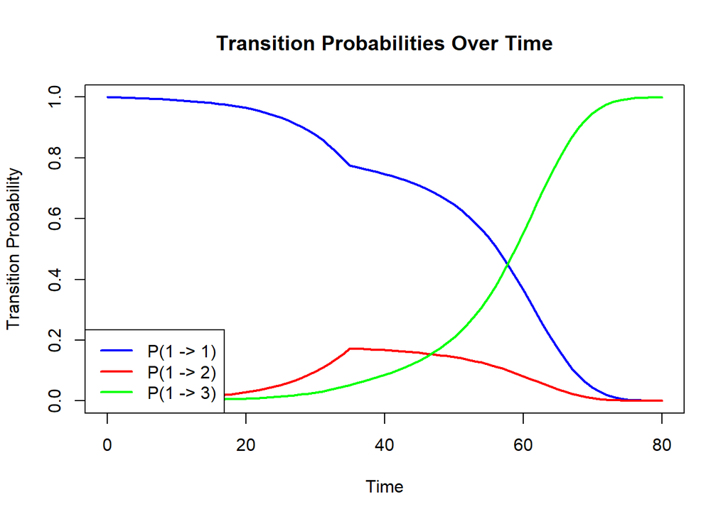

```r
P11 <- numeric(length(end_times))
P12 <- numeric(length(end_times))
P13 <- numeric(length(end_times))

for (i in seq_along(end_times)) {
  end_time <- end_times[i]
  prod_matrix <- lifepack::prodint(Lambda, start_time, end_time, num_steps)
  P11[i] <- prod_matrix[1, 1]
  P12[i] <- prod_matrix[1, 2]
  P13[i] <- prod_matrix[1, 3]
}

plot(end_times, P11, type = "l", col = "blue", lwd = 2,
     xlab = "Time", ylab = "Transition Probability",
     main = "Transition Probabilities Over Time")
lines(end_times, P12, col = "red", lwd = 2)
lines(end_times, P13, col = "green", lwd = 2)

legend("bottomleft", legend = c("P(1 -> 1)", "P(1 -> 2)", "P(1 -> 3)"),
       col = c("blue", "red", "green"), lty = 1, lwd = 2)
```

```r
list(
  data.frame(transition = "s = 25",
             p11 = prodint(Lambda1, 0 ,25, 1000)[1,1],
             p12 = prodint(Lambda1, 0 ,25, 1000)[1,2],
             p13 = prodint(Lambda1, 0 ,25, 1000)[1,3]),
  data.frame(transition = "s = 35",
             p11 = prodint(Lambda1, 0 ,35, 1000)[1,1],
             p12 = prodint(Lambda1, 0 ,35, 1000)[1,2],
             p13 = prodint(Lambda1, 0 ,35, 1000)[1,3])
)
```

```
## [[1]]
##   transition       p11        p12        p13
## 1     s = 25 0.9519117 0.02685201 0.02123634
##
## [[2]]
##   transition       p11        p12        p13
## 1     s = 35 0.8736452 0.05891422 0.06744058
```

Vores resultater virker fornuftige.

# Opgave i)

Vi regner det forventede tilstandsvise cash flow som givet ift.:
$$\begin{align*}
a(s,t)=P(s,t)R(t) e.
\end{align*}$$

Dette giver en vektor, hvoraf vi kan hive resultatet for tilstand $i = 1,2,3$ ud.

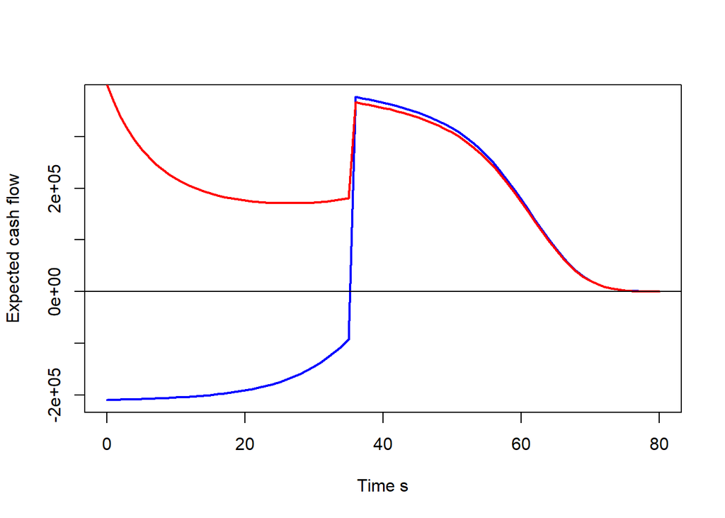

```r
eq    <- 209640.5
start <- 0
end_s <- 0:80
steps <- 1000

e_vec <- c(1, 1, 1)

a0_0 <- numeric(length(end_s))
a0_1 <- numeric(length(end_s))

for (i in seq_along(end_s)) {
  s <- end_s[i]
  P_mat <- prodint(Lambda, start, s, steps)
  R_mat     <- R(s, eq)
  a_vec     <- P_mat %*% R_mat %*% e_vec
  a0_0[i]   <- a_vec[1]
  a0_1[i]   <- a_vec[2]
}

plot(end_s, a0_0, type = "l", col = "blue", lwd = 2,
     xlab = "Time s", ylab = "Expected cash flow")
lines(end_s, a0_1, col = "red", lwd = 2)
abline(0,0)
```

```r
sel_s <- c(20, 35)
df_values <- data.frame(
  s       = sel_s,
  a0_0    = a0_0[end_s %in% sel_s],
  a0_1    = a0_1[end_s %in% sel_s]
)
df_values
```

| s | a0_0 | a0_1 |
| --- | --- | --- |
| 20 | -190857.38 | 176395.0 |
| 35 | -93047.78 | 180484.8 |

# Opgave j)

Vi skal regne markedsværdien for kontrakten, hvilket er reserven udregnet på baggrund af markedsværdigrundlaget.
$$\begin{align*}
V_0^\circ(0)=\int_0^{80}e^{\int_t^u r(v)dv}a_0^\circ(t,u)du.
\end{align*}$$

```r
eq    <- 209640.5
t <- 0

reserveR(t,80, Lambda1, R, eq, rentefun, 1000)[1]
```

```
## [1] -2160684
```

# opgave k)

$\textbf{Antag}$: $c(t) - \delta(t) > 0 \hspace{0.5cm} \forall t \in \mathbb{R}_+$.

Vi ved at $V^*(t) \geq 0 \hspace{0.5cm} \forall t \in \mathbb{R}_+$, da vi benytter ækvivalenspræmien regnet ud fra førsteordensgrundlaget. Fra tidligere inspektion af Risikosummerne har vi at

$$\begin{align*}
RS_{01}(t) \geq & 0\\
RS_{02}(t) \leq & 0\\
RS_{10}(t) \leq & 0 \\
RS_{12} \leq & 0\\
\end{align*}$$
Dertil kan vi ved benyttelse af theorem 6.5 skrive:
$$\begin{align*}
c(t) = (r(t)-r^\delta(t))V^*(t) + \sum_{j \in E \land j \neq X(t,
\omega)} (\mu_{X(t,\omega),j}(t)-
\mu_{X(t,\omega),j}(t))RS^*_{X(t,\omega),j} > \delta(t)
\end{align*}$$
Hvorved vi benytter vores antagelse om at $c(t) - \delta(t) > 0$ og derved udleder de nødvendige krav for $r^\delta(t)$ og $\alpha_{i,j}$. For at ovenstående skal gælde har vi

$$\begin{align*}
r(t) & \geq r^\delta(t)\\
\mu_{01}^\delta(t) & \geq \mu_{01}(t)\\
\mu_{02}^\delta(t) & \leq \mu_{02}(t)\\
\mu_{10}^\delta(t) & \leq \mu_{10}(t)\\
\mu_{12}^\delta(t) & \leq \mu_{12}(t)
\end{align*}$$

Vi kan nu benytte os af vores $\mu_{01}^\delta(t)$ og $\mu_{02}^\delta(t)$ til at finde vores $\alpha_{i,j}$.

$$\begin{align*}
\alpha_{01} = \frac{\mu_{01}^\delta(t)}{\mu_{01}(t)} \geq 1\\
\alpha_{02} = \frac{\mu_{02}^\delta(t)}{\mu_{02}(t)} \leq 1\\
\alpha_{10} = \frac{\mu_{10}^\delta(t)}{\mu_{10}(t)} \leq 1\\
\alpha_{12} = \frac{\mu_{12}^\delta(t)}{\mu_{12}(t)} \leq 1
\end{align*}$$

hvorved vi har fundet de nødvendige krav.